# Music and mood

Akriti Acharya

2026-09-8

```r
library(tidyverse)
```

# Intro:

For my project, I’m using the mxmh survey dataset, which has 736 responses and 33 columns. The data includes things like age, favorite genre, hours spent listening to music each day, and whether people listen while working. It also has mental health information such as anxiety, depression, insomnia, and OCD scores, plus whether people feel music improves, worsens, or has no effect on their mood.

This dataset is useful because it connects music habits with mental health and focus. That means I can look at questions like: do certain genres (like lo‑fi, pop, or rap) relate to lower anxiety? Does listening while working help people focus? Or does the tempo (BPM) of music make a difference in how people feel?

# Looking at the data

```r
mxmh_survey_results <- read_csv("mxmh_survey_results.csv")
# Looking at the first few rows

head(mxmh_survey_results)
```

```
## # A tibble: 6 × 33
##   Timestamp           Age Primary streaming se…¹ `Hours per day` `While working`
##   <chr>             <dbl> <chr>                            <dbl> <chr>
## 1 8/27/2022 19:29:…    18 Spotify                            3   Yes
## 2 8/27/2022 19:57:…    63 Pandora                            1.5 Yes
## 3 8/27/2022 21:28:…    18 Spotify                            4   No
## 4 8/27/2022 21:40:…    61 YouTube Music                      2.5 Yes
## 5 8/27/2022 21:54:…    18 Spotify                            4   Yes
## 6 8/27/2022 21:56:…    18 Spotify                            5   Yes
## # ℹ abbreviated name: ¹`Primary streaming service`
## # ℹ 28 more variables: Instrumentalist <chr>, Composer <chr>,
## #   `Fav genre` <chr>, Exploratory <chr>, `Foreign languages` <chr>, BPM <dbl>,
## #   `Frequency [Classical]` <chr>, `Frequency [Country]` <chr>,
## #   `Frequency [EDM]` <chr>, `Frequency [Folk]` <chr>,
## #   `Frequency [Gospel]` <chr>, `Frequency [Hip hop]` <chr>,
## #   `Frequency [Jazz]` <chr>, `Frequency [K pop]` <chr>, …
```

```r
# Column names
names(mxmh_survey_results)
```

```
##  [1] "Timestamp"                    "Age"
##  [3] "Primary streaming service"    "Hours per day"
##  [5] "While working"                "Instrumentalist"
##  [7] "Composer"                     "Fav genre"
##  [9] "Exploratory"                  "Foreign languages"
## [11] "BPM"                          "Frequency [Classical]"
## [13] "Frequency [Country]"          "Frequency [EDM]"
## [15] "Frequency [Folk]"             "Frequency [Gospel]"
## [17] "Frequency [Hip hop]"          "Frequency [Jazz]"
## [19] "Frequency [K pop]"            "Frequency [Latin]"
## [21] "Frequency [Lofi]"             "Frequency [Metal]"
## [23] "Frequency [Pop]"              "Frequency [R&B]"
## [25] "Frequency [Rap]"              "Frequency [Rock]"
## [27] "Frequency [Video game music]" "Anxiety"
## [29] "Depression"                   "Insomnia"
## [31] "OCD"                          "Music effects"
## [33] "Permissions"
```

```r
# Summary statistics
summary(mxmh_survey_results)
```

```
##   Timestamp              Age        Primary streaming service Hours per day
##  Length:736         Min.   :10.00   Length:736                Min.   : 0.000
##  Class :character   1st Qu.:18.00   Class :character          1st Qu.: 2.000
##  Mode  :character   Median :21.00   Mode  :character          Median : 3.000
##                     Mean   :25.21                             Mean   : 3.573
##                     3rd Qu.:28.00                             3rd Qu.: 5.000
##                     Max.   :89.00                             Max.   :24.000
##                     NA's   :1
##  While working      Instrumentalist      Composer          Fav genre
##  Length:736         Length:736         Length:736         Length:736
##  Class :character   Class :character   Class :character   Class :character
##  Mode  :character   Mode  :character   Mode  :character   Mode  :character
##
##
##
##
##  Exploratory        Foreign languages       BPM           Frequency [Classical]
##  Length:736         Length:736         Min.   :0.00e+00   Length:736
##  Class :character   Class :character   1st Qu.:1.00e+02   Class :character
##  Mode  :character   Mode  :character   Median :1.20e+02   Mode  :character
##                                        Mean   :1.59e+06
##                                        3rd Qu.:1.44e+02
##                                        Max.   :1.00e+09
##                                        NA's   :107
##  Frequency [Country] Frequency [EDM]    Frequency [Folk]   Frequency [Gospel]
##  Length:736          Length:736         Length:736         Length:736
##  Class :character    Class :character   Class :character   Class :character
##  Mode  :character    Mode  :character   Mode  :character   Mode  :character
##
##
##
##
##  Frequency [Hip hop] Frequency [Jazz]   Frequency [K pop]  Frequency [Latin]
##  Length:736          Length:736         Length:736         Length:736
##  Class :character    Class :character   Class :character   Class :character
##  Mode  :character    Mode  :character   Mode  :character   Mode  :character
##
##
##
##
```

[output cut: 17 more lines]

```
##  Min.   : 0.000   Min.   : 0.000   Min.   : 0.000   Min.   : 0.000
##  1st Qu.: 4.000   1st Qu.: 2.000   1st Qu.: 1.000   1st Qu.: 0.000
##  Median : 6.000   Median : 5.000   Median : 3.000   Median : 2.000
##  Mean   : 5.838   Mean   : 4.796   Mean   : 3.738   Mean   : 2.637
##  3rd Qu.: 8.000   3rd Qu.: 7.000   3rd Qu.: 6.000   3rd Qu.: 5.000
##  Max.   :10.000   Max.   :10.000   Max.   :10.000   Max.   :10.000
##
##  Music effects      Permissions
##  Length:736         Length:736
##  Class :character   Class :character
##  Mode  :character   Mode  :character
##
##
##
##
```

```r
# Genre counts
table(mxmh_survey_results$`Fav genre`)
```

```
##
##        Classical          Country              EDM             Folk
##               53               25               37               30
##           Gospel          Hip hop             Jazz            K pop
##                6               35               20               26
##            Latin             Lofi            Metal              Pop
##                3               10               88              114
##              R&B              Rap             Rock Video game music
##               35               22              188               44
```

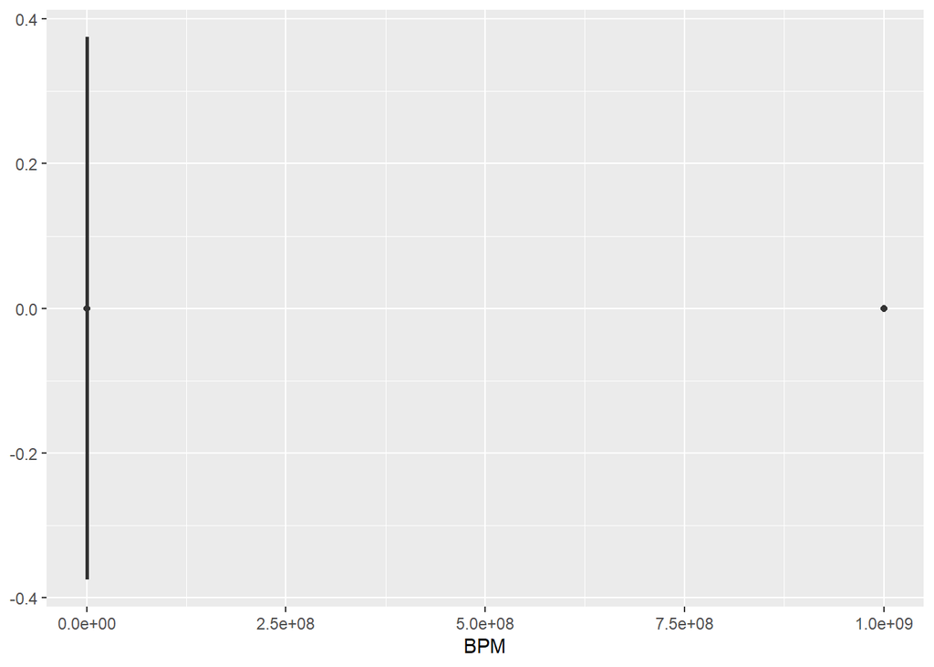

```r
ggplot(mxmh_survey_results,aes(x=BPM))+
  geom_boxplot()
```

```r
mxmh_survey_results %>%
  filter(BPM>1000)
```

```
## # A tibble: 1 × 33
##   Timestamp           Age Primary streaming se…¹ `Hours per day` `While working`
##   <chr>             <dbl> <chr>                            <dbl> <chr>
## 1 9/4/2022 15:41:59    16 Spotify                              7 Yes
## # ℹ abbreviated name: ¹`Primary streaming service`
## # ℹ 28 more variables: Instrumentalist <chr>, Composer <chr>,
## #   `Fav genre` <chr>, Exploratory <chr>, `Foreign languages` <chr>, BPM <dbl>,
## #   `Frequency [Classical]` <chr>, `Frequency [Country]` <chr>,
## #   `Frequency [EDM]` <chr>, `Frequency [Folk]` <chr>,
## #   `Frequency [Gospel]` <chr>, `Frequency [Hip hop]` <chr>,
## #   `Frequency [Jazz]` <chr>, `Frequency [K pop]` <chr>, …
```

```r
is.na(mxmh_survey_results$BPM)<- mxmh_survey_results$BPM > 1000
```

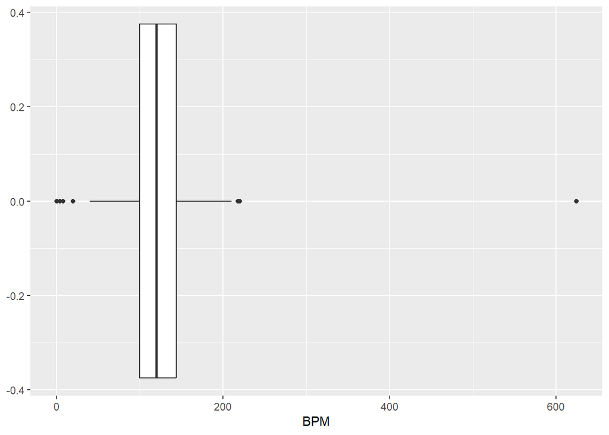

```r
ggplot(mxmh_survey_results,aes(x=BPM))+
  geom_boxplot()
```

#Check for any missing values

```r
colSums(is.na(mxmh_survey_results))
```

```
##                    Timestamp                          Age
##                            0                            1
##    Primary streaming service                Hours per day
##                            1                            0
##                While working              Instrumentalist
##                            3                            4
##                     Composer                    Fav genre
##                            1                            0
##                  Exploratory            Foreign languages
##                            0                            4
##                          BPM        Frequency [Classical]
##                          108                            0
##          Frequency [Country]              Frequency [EDM]
##                            0                            0
##             Frequency [Folk]           Frequency [Gospel]
##                            0                            0
##          Frequency [Hip hop]             Frequency [Jazz]
##                            0                            0
##            Frequency [K pop]            Frequency [Latin]
##                            0                            0
##             Frequency [Lofi]            Frequency [Metal]
##                            0                            0
##              Frequency [Pop]              Frequency [R&B]
##                            0                            0
##              Frequency [Rap]             Frequency [Rock]
##                            0                            0
## Frequency [Video game music]                      Anxiety
##                            0                            0
##                   Depression                     Insomnia
##                            0                            0
##                          OCD                Music effects
##                            0                            8
##                  Permissions
##                            0
```

#Summary stats for quantative variable

```r
summary(mxmh_survey_results[, c("Age", "Hours per day", "BPM",
                                "Anxiety", "Depression", "Insomnia", "OCD")])
```

```
##       Age        Hours per day         BPM           Anxiety
##  Min.   :10.00   Min.   : 0.000   Min.   :  0.0   Min.   : 0.000
##  1st Qu.:18.00   1st Qu.: 2.000   1st Qu.:100.0   1st Qu.: 4.000
##  Median :21.00   Median : 3.000   Median :120.0   Median : 6.000
##  Mean   :25.21   Mean   : 3.573   Mean   :123.4   Mean   : 5.838
##  3rd Qu.:28.00   3rd Qu.: 5.000   3rd Qu.:144.0   3rd Qu.: 8.000
##  Max.   :89.00   Max.   :24.000   Max.   :624.0   Max.   :10.000
##  NA's   :1                        NA's   :108
##    Depression        Insomnia           OCD
##  Min.   : 0.000   Min.   : 0.000   Min.   : 0.000
##  1st Qu.: 2.000   1st Qu.: 1.000   1st Qu.: 0.000
##  Median : 5.000   Median : 3.000   Median : 2.000
##  Mean   : 4.796   Mean   : 3.738   Mean   : 2.637
##  3rd Qu.: 7.000   3rd Qu.: 6.000   3rd Qu.: 5.000
##  Max.   :10.000   Max.   :10.000   Max.   :10.000
##
```

# Distribution of Favorite Genres

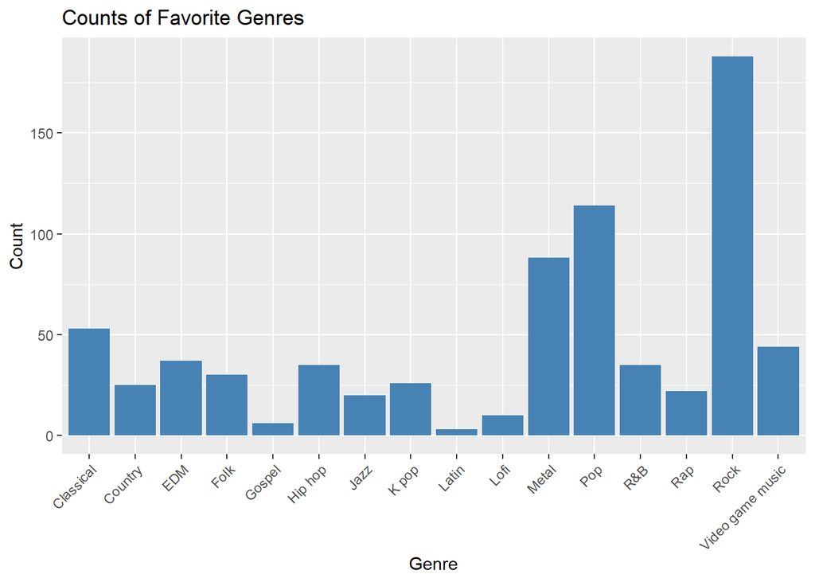

```r
library(ggplot2)

ggplot(mxmh_survey_results, aes(x = `Fav genre`)) +
  geom_bar(fill = "steelblue") +
  labs(title = "Counts of Favorite Genres",
       x = "Genre",
       y = "Count") +
  theme(axis.text.x = element_text(angle = 45, hjust = 1))
```

We can see that rock is the most common favorite genre, followed by Pop and Metal, while Gospel and Latin have the fewest responses.This shows which genres are most popular in the dataset.

# Average Anxiety Score by Genre

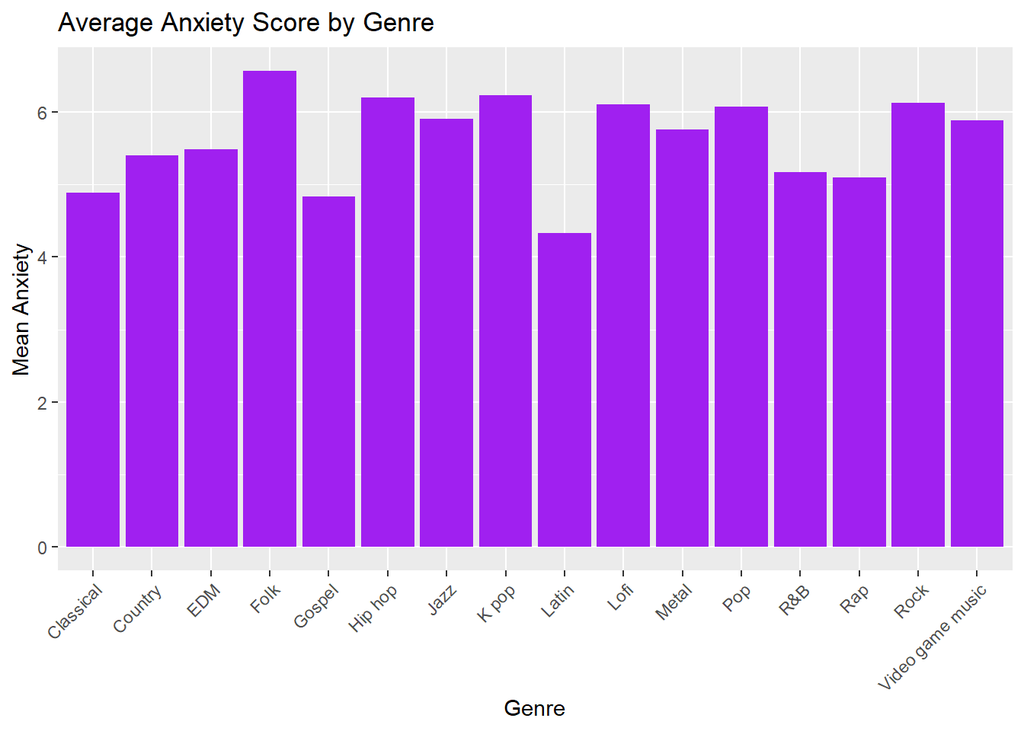

```r
mxmh_survey_results %>%
  group_by(`Fav genre`) %>%
  summarise(mean_anxiety = mean(Anxiety, na.rm = TRUE)) %>%
  ggplot(aes(x = `Fav genre`, y = mean_anxiety)) +
  geom_col(fill = "purple") +
  labs(title = "Average Anxiety Score by Genre",
       x = "Genre",
       y = "Mean Anxiety") +
  theme(axis.text.x = element_text(angle = 45, hjust = 1))
```

# Depression by Genre

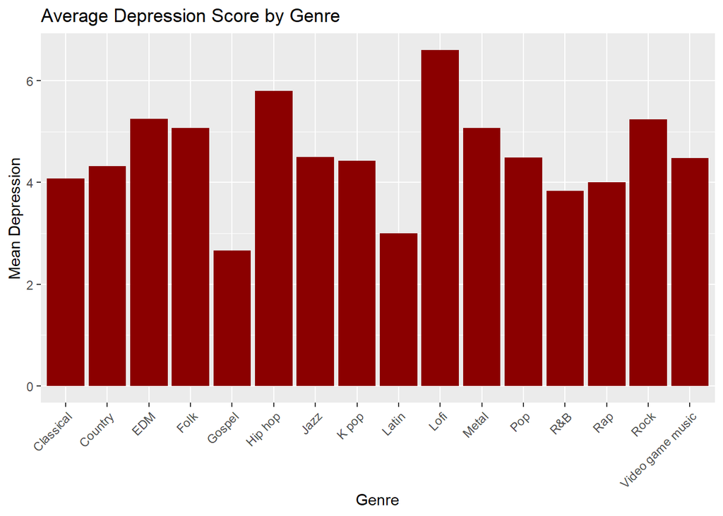

```r
mxmh_survey_results %>%
  group_by(`Fav genre`) %>%
  summarise(mean_depression = mean(Depression, na.rm = TRUE)) %>%
  ggplot(aes(x = `Fav genre`, y = mean_depression)) +
  geom_col(fill = "darkred") +
  labs(title = "Average Depression Score by Genre",
       x = "Genre",
       y = "Mean Depression") +
  theme(axis.text.x = element_text(angle = 45, hjust = 1))
```

This chart shows that lo‑fi, hip hop, and EDM listeners report higher average depression scores, while gospel and Latin listeners report the lowest. It suggests certain genres may be linked with higher or lower depression levels.

#Music effects bar chart

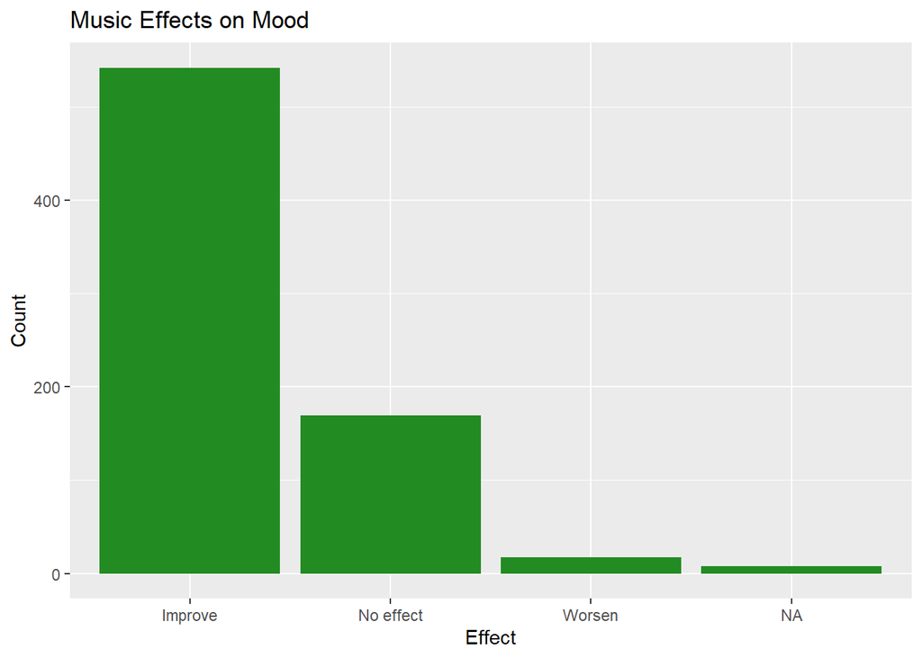

```r
ggplot(mxmh_survey_results, aes(x = `Music effects`)) +
  geom_bar(fill = "forestgreen") +
  labs(title = "Music Effects on Mood",
       x = "Effect",
       y = "Count")
```

Looking at the chart, most participants said music improves their mood, with far fewer reporting no effect or worsened mood. This indicates that overall, music is strongly associated with positive emotional wellbeing.